# Tidybiology Final Project

Swathi Suratkal

September 30, 2022

## Aging, Dementia and Traumatic Brain Injury Study

I obtained two datasets from the Aging, Dementia and Traumatic Brain Injury Study at https://aging.brain-map.org/download/index

The first dataset, **donor**, contained the de-identified patient information such as extent of cognitive impairment and age of TBI. The second dataset, **protein** had expression values for key dementia-associated proteins in tissue specimen from these donors.

I wanted to combine the two so I could explore the relationship between protein expression and the manifesting pathology.I named this new dataset **combined_data**

#Combined_data

```
## Rows: 377
## Columns: 51
## $ donor_id.x                <dbl> 326765665, 326765665, 326765656, 326765656, …
## $ name                      <chr> "H14.09.078", "H14.09.078", "H14.09.069", "H…
## $ age                       <chr> "87", "87", "95-99", "95-99", "95-99", "95-9…
## $ sex                       <chr> "M", "M", "M", "M", "M", "M", "M", "M", "M",…
## $ apo_e4_allele             <chr> "N", "N", "N", "N", "N", "N", "Y", "Y", "Y",…
## $ education_years           <dbl> 16, 16, 17, 17, 17, 17, 10, 10, 10, 10, 11, …
## $ age_at_first_tbi          <dbl> 0, 0, 12, 12, 12, 12, 72, 72, 72, 72, 87, 87…
## $ longest_loc_duration      <chr> "Unknown or N/A", "Unknown or N/A", "1-2 min…
## $ cerad                     <dbl> 0, 0, 2, 2, 2, 2, 3, 3, 3, 3, 0, 0, 0, 0, 3,…
## $ num_tbi_w_loc             <dbl> 0, 0, 1, 1, 1, 1, 1, 1, 1, 1, 1, 1, 1, 1, 0,…
## $ dsm_iv_clinical_diagnosis <chr> "No Dementia", "No Dementia", "No Dementia",…
## $ control_set               <dbl> 31, 31, 26, 26, 26, 26, 25, 25, 25, 25, 52, …
## $ nincds_arda_diagnosis     <chr> "No Dementia", "No Dementia", "No Dementia",…
```

[output cut: 38 more lines]

#Exploring correlation of protein expression to cognitive impairment

First, I tried out different proteins against the CERAD score, which is a measure of cognitive impairment ranging from 0 to 3, with 3 being the greatest.

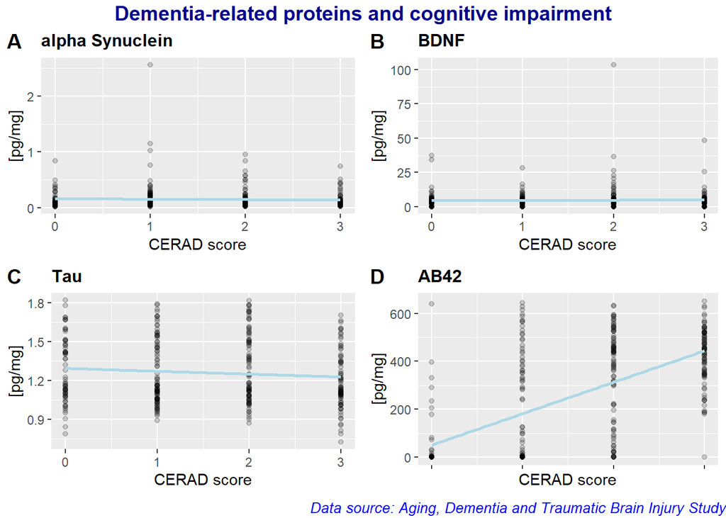

We see that AB42 protein expression levels seem to be the most correlated with the extent of CI. I wanted to visualize this according to the brain region assayed.

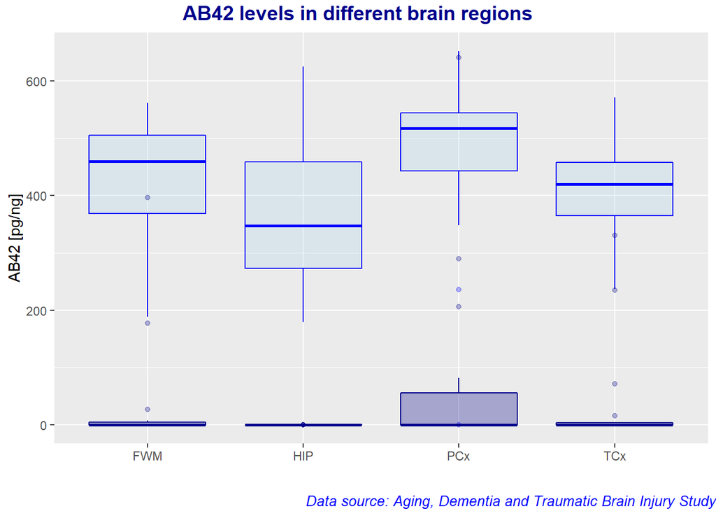

## Final Graph

Now I wanted to bring in the effect of traumatic brain injury on this phenomenon. I noticed that the TBI age in the dataset seemed to be either at birth or later. Obstetric complications are closely linked to neuropathology later in life. To look at this in this dataset, I split it into TBI at birth and TBI after birth.

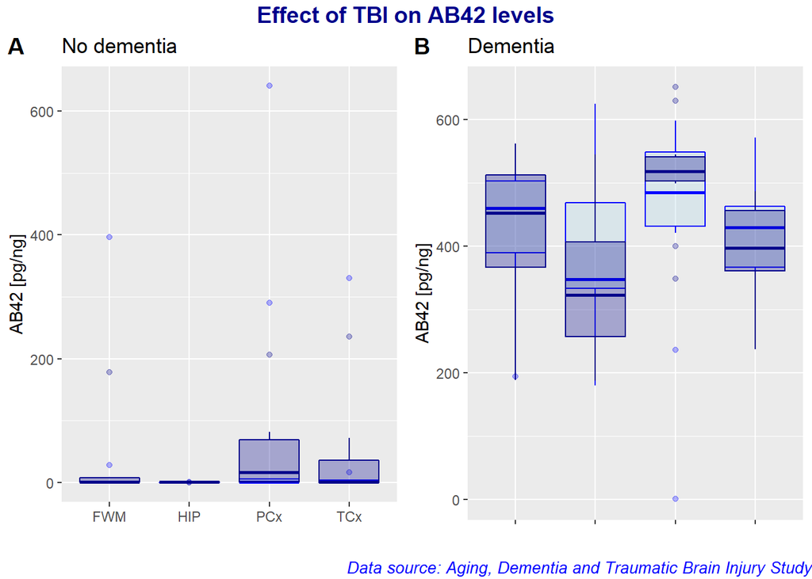

## Prioritized follow-up studies

1. Look at datasets with donors who have not suffered TBI
2. Look at AB42 levels in younger individuals with TBI + no CI
3. Have more qualitative information on the kind of TBI, brain region affected
4. More rigorous stats needed

## Acknolwedgements

Thank you Prof Matthew Hirschey for this amazing week! Thank you Charles for helping us out when we were stuck. Thank you Sam for lending me your laptop and the moral support in class

```r
#PROBABLY BEST TO LEAVE THIS HERE, BUT NO NEED TO PRINT IN THE FINAL REPORT.

#You can remove an item from sessionInfo(), which is a list with a class attribute, by printing the resulting object omitting one of the list items (omitted list of packages installed, but not loaded)
```